# 105.4. Synthetic source injection

For the Rubin Science Platform at data.lsst.cloud.  
Data Release: [Data Preview 1](https://dp1.lsst.io/)  
Container Size: large  
LSST Science Pipelines version: r29.2.0  
Last verified to run: 2025-11-03  
Repository: github.com/lsst/tutorial-notebooks

**Learning objective:** Use LSST Science Pipelines tools to inject synthetic sources into images.

**LSST data products:** `visit_image`

**Packages:** `lsst.source.injection`, `lsst.daf.butler`, `lsst.afw.display`

**Credit:** Originally developed by Jeff Carlin in collaboration with Lee Kelvin and the Rubin Community Science Team. Much of the material is based on the documentation for the LSST [source_injection package](https://pipelines.lsst.io/v/daily/modules/lsst.source.injection/index.html). Please consider acknowledging them if this notebook is used for the preparation of journal articles, software releases, or other notebooks.

**Get Support:** Everyone is encouraged to ask questions or raise issues in the [Support Category](https://community.lsst.org/c/support) of the Rubin Community Forum. Rubin staff will respond to all questions posted there.

## 1. Introduction

This notebook demonstrates the use of the `source_injection` package from the LSST Science Pipelines to inject artificial sources (stars and galaxies) into images using the images' measured point-spread function, WCS, and photometric calibration. Sources can be injected into images produced during various stages of Pipelines processing, including visit-level images (e.g., `visit_image`s), any dataset with a `datasetType` of `Exposure` (e.g., `post_isr_image`s), and coadd images (e.g., `deep_coadd`s). The driver that both creates and injects synthetic sources into images is based on [Galsim](https://galsim-developers.github.io/GalSim/), enabling injection of many types of sources, including stars, a variety of parameterized galaxy models, and postage stamp images.

This notebook teaches some basics of using the `source_injection` package to insert artificial sources into images. Read the extensive [documentation](https://pipelines.lsst.io/v/daily/modules/lsst.source.injection/index.html) for more details and examples. Furthermore, the [Galsim](https://galsim-developers.github.io/GalSim/) documentation provides much more detail on the types of sources that can be injected.

**Related tutorials:** Detect and measure sources, Forced photometry

### 1.1. Import packages

Import `numpy`, a fundamental package for scientific computing with arrays in Python (numpy.org), and `matplotlib`, a comprehensive library for data visualization ([matplotlib.org](https://matplotlib.org/); [matplotlib gallery](https://matplotlib.org/stable/gallery/index.html)). Tools from [Astropy](https://www.astropy.org/) will be used to read a FITS image an work with Tables.

From the `lsst` package, import the butler, the `lsst.source.injection` package to inject synthetic sources into images, and image display functions from the LSST Science Pipelines ([pipelines.lsst.io](https://pipelines.lsst.io/)).

```python
import matplotlib.pyplot as plt
from lsst.daf.butler import Butler
import lsst.afw.display as afwDisplay

from astropy.io import fits
from astropy.table import Table, vstack

from lsst.source.injection import generate_injection_catalog
from lsst.source.injection import VisitInjectConfig, VisitInjectTask
```

### 1.2. Define parameters and functions

Set `afwDisplay` to use matplotlib.

```python
afwDisplay.setDefaultBackend("matplotlib")
```

Instantiate the Butler pointing to the DP1 repository and collection, and assert it exists.

```python
butler = Butler("dp1", collections="LSSTComCam/DP1")
assert butler is not None
```

## 2. Retrieve an image

### 2.1. Select a `visit_image`

Identify images overlapping a particular sky position and select one to inject sources into.

Query the butler for $r$-band `visit_image`s from detector number 4 that overlap a given RA, Dec position, and select one to use for source injection.

```python
ra = 53.076
dec = -28.110
band = 'r'
```

```python
query = f"band='{band}' AND detector=4 AND \
          visit_detector_region.region OVERLAPS POINT({ra}, {dec})"

visit_img_refs = butler.query_datasets('visit_image',
                                       where=query)
```

```python
visit_img = butler.get(visit_img_refs[0])
```

#### 2.1.1. Extract the image center and dimensions

To generate synthetic sources to inject into the image, the coordinates and size of its bounding box are necessary.

Use the image's WCS and bounding box to extract the central (RA, Dec) coordinate and image size (in degrees), and print those to the screen.

```python
cen = visit_img.wcs.pixelToSky(visit_img.getBBox().getCenter())
imsize = visit_img.getBBox().getDimensions()*visit_img.wcs.getPixelScale().asDegrees()

print('Image center in (RA, Dec): ', cen)
print('Size of visit_image in degrees: ', imsize)
```

```
Image center in (RA, Dec):  (53.1379468189, -28.0732505763)
Size of visit_image in degrees:  (0.22652, 0.22252)
```

## 3. Make a catalog of synthetic sources

Having retrieved a `visit_image` to inject into, now set up a simple synthetic source catalog.

### 3.1. Make a catalog of galaxies and stars

The `source_injection` package provides tools to create catalogs of synthetic sources. Here, use the `generate_injection_catalog` function to create the sources to inject.

Note that the "inject_size" is selected to be 0.1 degrees, or slightly smaller than the size of the image as determined above (inject_size is a radius, so it equals 0.2/2 degrees).

```python
inject_size = 0.2/2
```

#### 3.1.1. Galaxies

The simplest form of a galaxy in Galsim is parameterized by a [Sersic model](https://en.wikipedia.org/wiki/S%C3%A9rsic_profile): $I(r) = I_e~{\rm exp}\{-b_n [(\frac{r}{r_e})^{1/n}-1]\}$, which defines the shape of the galaxy's light profile as a function of radius (r) in terms of the "Sersic index" (n) and the "half-light radius" ($r_e$). (Note that $n = 1$ corresponds to an exponential profile.)

The above equation results in a circular galaxy. To create elongated (elliptical) Sersic profiles, additionally specify the minor-to-major axis ratio (q) with a rotation angle (beta).

Finally, provide minimum and maximum RA and Dec coordinates in degrees. In this case, `generate_injection_catalog` will randomly select positions within those limits.

```python
my_injection_catalog_galaxies = generate_injection_catalog(
    ra_lim=[cen.getRa().asDegrees()-inject_size, cen.getRa().asDegrees()+inject_size],
    dec_lim=[cen.getDec().asDegrees()-inject_size, cen.getDec().asDegrees()+inject_size],
    number=2,
    seed='3210',
    source_type="Sersic",
    mag=[15.0],
    n=[1, 2, 4],
    q=[0.9, 0.5, 0.1],
    beta=[31.0, 144.0],
    half_light_radius=[5.0],
)
```

```
lsst.source.injection.utils._generate_injection_catalog INFO: Generated an injection catalog containing 36 sources: 18 combinations repeated 2 times.
```

#### 3.1.2. Stars

Using a similar method, create a catalog of stars to be injected. Specify 7 values of magnitude, with 7 instances, which will result in 49 stars.

```python
my_injection_catalog_stars = generate_injection_catalog(
    ra_lim=[cen.getRa().asDegrees()-inject_size, cen.getRa().asDegrees()+inject_size],
    dec_lim=[cen.getDec().asDegrees()-inject_size, cen.getDec().asDegrees()+inject_size],
    number=7,
    seed='432',
    mag=[19.0, 19.5, 20.0, 20.5, 21.0, 21.5, 22.0],
    source_type="Star",
)
```

```
lsst.source.injection.utils._generate_injection_catalog INFO: Generated an injection catalog containing 49 sources: 7 combinations repeated 7 times.
```

#### 3.1.3. Combine catalogs

Before combining the catalogs, offset the `injection_id` values for the star catalog by 1000 to avoid overlapping with the galaxy ids.

Use the [vstack](https://docs.astropy.org/en/stable/table/operations.html#id4) method from Astropy's [Table](https://docs.astropy.org/en/stable/table/index.html) class to combine the galaxy and star catalogs.

```python
my_injection_catalog_stars['injection_id'] += 1000

inject_cat = vstack([my_injection_catalog_galaxies, my_injection_catalog_stars])
```

Inspect the catalog.

```python
inject_cat
```

*Table length=85*

| injection_id int64 | ra float64 | dec float64 | source_type str6 | mag float64 | n int64 | q float64 | beta float64 | half_light_radius float64 |
| --- | --- | --- | --- | --- | --- | --- | --- | --- |
| 0 | 53.228239896616735 | -28.106616457094464 | Sersic | 15.0 | 1 | 0.9 | 31.0 | 5.0 |
| 1 | 53.109489896616736 | -27.98315966697101 | Sersic | 15.0 | 1 | 0.9 | 31.0 | 5.0 |
| 10 | 53.046989896616736 | -28.01032016079817 | Sersic | 15.0 | 1 | 0.9 | 144.0 | 5.0 |
| 11 | 53.040739896616735 | -28.15846830894632 | Sersic | 15.0 | 1 | 0.9 | 144.0 | 5.0 |
| 20 | 53.18448989661673 | -28.11649300030434 | Sersic | 15.0 | 1 | 0.5 | 31.0 | 5.0 |
| 21 | 53.12823989661673 | -28.091801642279652 | Sersic | 15.0 | 1 | 0.5 | 31.0 | 5.0 |
| 30 | 53.09073989661673 | -28.00291275339076 | Sersic | 15.0 | 1 | 0.5 | 144.0 | 5.0 |
| 31 | 53.15948989661673 | -28.00538188919323 | Sersic | 15.0 | 1 | 0.5 | 144.0 | 5.0 |
| 40 | 53.05323989661673 | -28.06217201265002 | Sersic | 15.0 | 1 | 0.1 | 31.0 | 5.0 |
| ... | ... | ... | ... | ... | ... | ... | ... | ... |
| 1054 | 53.10965263826026 | -28.004947737655698 | Star | 21.5 | -- | -- | -- | -- |
| 1055 | 53.21277763826026 | -27.99260205864335 | Star | 21.5 | -- | -- | -- | -- |
| 1056 | 53.16277763826026 | -28.08149094753224 | Star | 21.5 | -- | -- | -- | -- |
| 1060 | 53.22527763826026 | -28.148157614198908 | Star | 22.0 | -- | -- | -- | -- |
| 1061 | 53.19090263826026 | -28.11852798456928 | Star | 22.0 | -- | -- | -- | -- |
| 1062 | 53.11277763826026 | -28.05926872531002 | Star | 22.0 | -- | -- | -- | -- |
| 1063 | 53.14715263826026 | -28.101244033951996 | Star | 22.0 | -- | -- | -- | -- |
| 1064 | 53.17527763826026 | -28.037046503087797 | Star | 22.0 | -- | -- | -- | -- |
| 1065 | 53.22840263826026 | -28.167910700618663 | Star | 22.0 | -- | -- | -- | -- |
| 1066 | 53.04715263826026 | -28.14568847839644 | Star | 22.0 | -- | -- | -- | -- |

### 3.2. Add a postage stamp image entry

In addition to parameterized sources of many types, a postage-stamp image (for example, an output image from a simulation) can also be injected. This can be any image; the only requirement is that it must be in FITS format and have a valid WCS (see a fun example [here](https://pipelines.lsst.io/v/d_2024_02_27/modules/lsst.source.injection/faqs.html#frequently-asked-questions-and-answers-about-synthetic-source-injection)). This notebook demonstrates injection of an [SDSS g-band image](https://ned.ipac.caltech.edu/byname?objname=NGC+4152&hconst=67.8&omegam=0.308&omegav=0.692&wmap=4&corr_z=1) of the galaxy PGC 038749 downloaded from the NASA/IPAC Extragalactic Database (NED).

Load the image, then display it to see what it depicts:

```python
stamp_path = '/rubin/cst_repos/tutorial-notebooks-data/data/'
stamp_img_hdu = fits.open(stamp_path + 'PGC_038749_I_g_bbl2011.fits')
```

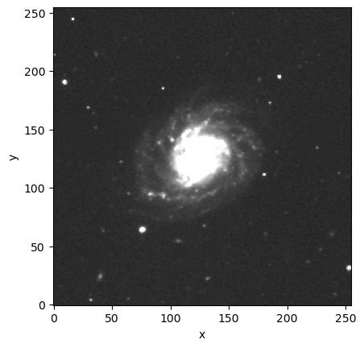

```python
fig = plt.figure()
plt.subplot()
im = plt.imshow(stamp_img_hdu[0].data, cmap='gray', vmin=-20.0, vmax=100, origin='lower')
plt.xlabel('x')
plt.ylabel('y')
plt.show()
```

> Figure 1: The SDSS g-band image of PGC 038749 displayed in grayscale, with axes in pixel coordinates.

Add a postage stamp entry into the injection catalog, using `vstack` to add an astropy `Table` containing a single row. Specify its position, magnitude, and "source_type = Stamp," in addition to the filename of the image to inject. (It is OK to leave unnecessary columns empty.)

```python
my_injection_catalog_stamp = Table(
    {
        'injection_id': [9999],
        'ra': [cen.getRa().asDegrees()+0.01],
        'dec': [cen.getDec().asDegrees()-0.01],
        'source_type': ['Stamp'],
        'mag': [14.8],
        'stamp': [stamp_path + 'PGC_038749_I_g_bbl2011.fits'],
    }
)

inject_cat = vstack([inject_cat, my_injection_catalog_stamp])
```

Option to view the injection catalog:

```python
# inject_cat
```

## 4. Inject sources into an image

In Section 3, a catalog specifying the synthetic sources to inject was created.

Now run the task from `source_injection` that injects sources into the `visit_image` that was retrieved earlier.

Pass the point spread function (PSF), photometric calibration object, and the WCS (World Coordinate System) associated with the `visit_image` that was retrieved earlier to the injection task so that sources can be injected using the properties of the image itself.

### 4.1. Instantiate the injection classes

First, instantiate the `VisitInjectConfig` class. The `VisitInjectConfig` class is where configuration of the injection task occurs, allowing for modifications to be made to how the task operates.

Then instantiate the `VisitInjectTask`, using `inject_config` as the configuration argument.

NOTE: For injections into other dataset types, use the appropriate option from the following list:

```
from lsst.source.injection import CoaddInjectConfig, CoaddInjectTask

from lsst.source.injection import ExposureInjectConfig, ExposureInjectTask

from lsst.source.injection import VisitInjectConfig, VisitInjectTask
```

Both `ExposureInject` and `VisitInject` accept dimensions of `("instrument", "visit", "detector")`. They differ in that `ExposureInject` takes a `post_isr_image` exposure (i.e., a raw image that has had "instrument signature removal," or ISR, applied, and no further processing) as an input, while `VisitInject` expects to operate on a `visit_image` (an image that has been astrometrically and photometrically calibrated to an external source).

```python
inject_config = VisitInjectConfig()

inject_task = VisitInjectTask(config=inject_config)
```

### 4.2. Run the source_injection task

Execute the `run` method of the `inject_task`.

The `run` method needs the following inputs:

- the input injection catalog
- the input `visit_image`
- the PSF of the input exposure
- the WCS information
- the photometric calibration information

The PSF, WCS, and photo_calib inputs are associated with the `visit_image` that was already retrieved.

The inject task provides two outputs:

- the output exposure with sources injected
- the output source injection catalog

The output source injection catalog is identical to the input, but with two additional columns (x and y) denoting the pixel coordinates of these sources. Note that this catalog is NOT the science catalog containing the full suite of LSST Science Pipelines outputs. To get that, this source injected image will need to be processed by additional Science Pipelines tasks.

> Note: it is best to use a clone of the input `visit_image`. This is because the `visit_image` that is input for source injection will be edited in-place. Inputting a clone makes it possible to compare the output image to the original `visit_image` later in this notebook.

Run the source injection task and extract the "output_exposure" and "output_catalog":

```python
injected_output = inject_task.run(
    injection_catalogs=inject_cat,
    input_exposure=visit_img.clone(),
    psf=visit_img.psf,
    photo_calib=visit_img.photoCalib,
    wcs=visit_img.wcs,
)
injected_exposure = injected_output.output_exposure
injected_catalog = injected_output.output_catalog
```

```
lsst.visitInjectTask INFO: Retrieved 86 injection sources from 86 HTM trixels.
```

```
lsst.visitInjectTask INFO: Catalog cleaning removed 0 of 86 sources; 86 remaining for catalog checking.
```

```
lsst.visitInjectTask INFO: Catalog checking flagged 0 of 86 sources; 86 remaining for source generation.
```

```
lsst.visitInjectTask INFO: Adding INJECTED and INJECTED_CORE mask planes to the exposure.
```

```
lsst.visitInjectTask INFO: Generating 86 injection sources consisting of 3 unique types: Sersic(36), DeltaFunction(49), Stamp(1).
```

```
lsst.visitInjectTask INFO: Injected 86 of 86 potential sources. 0 sources flagged and skipped.
```

### 4.3. Compare the images before and after injection

Display the images in separate panels with matplotlib, and compare them to confirm that the sources have been injected.

Optionally, uncomment the commented-out "display1.mtv" cell to zoom in on the injected stamp image.

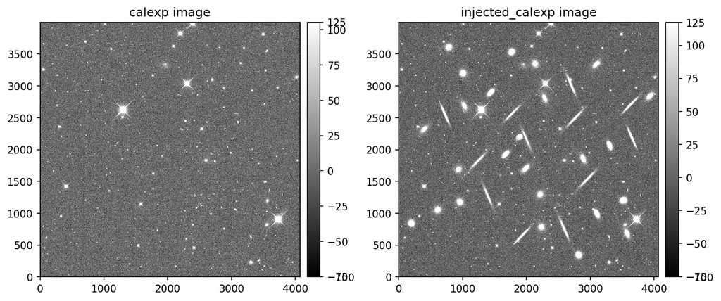

```python
plot_injected_img = injected_exposure.clone()

fig, ax = plt.subplots(1, 2, figsize=(10, 6), dpi=150)

plt.sca(ax[0])
display0 = afwDisplay.Display(frame=fig)
display0.scale('linear', 'zscale')
display0.mtv(visit_img.image)
plt.title('calexp image')

plt.sca(ax[1])
display1 = afwDisplay.Display(frame=fig)
display1.scale('linear', 'zscale')
display1.mtv(plot_injected_img.image)
# To zoom on the PGC 038749 stamp:
# display1.mtv(plot_injected_img.image[1700:2200, 1950:2450])
plt.title('injected_calexp image')

plt.tight_layout()
plt.show()
```